# Multi-Class Image Classification Deep Learning Model for Flower Photos Using TensorFlow Take 2

### February 22, 2021

Template Credit: Adapted from a template made available by Dr. Jason Brownlee of Machine Learning Mastery. [https://machinelearningmastery.com/]

SUMMARY: This project aims to construct a predictive model using a TensorFlow convolutional neural network (CNN) and document the end-to-end steps using a template. The Flower Photos dataset is a multi-class classification situation where we attempt to predict one of several (more than two) possible outcomes.

INTRODUCTION: The Flower Photos dataset is a collection of 3670 flower photos in five different species. This dataset is part of the TensorFlow standard dataset collection.

From iteration Take1, we constructed and tuned a machine learning model using a simple three-layer MLP network. We also observed the best result that we could obtain using the validation dataset.

In this Take2 iteration, we will construct and tune a machine learning model using the VGG-16 architecture. We will also observe the best result that we can obtain using the validation dataset.

ANALYSIS: From iteration Take1, the baseline model's performance achieved an accuracy score of 80.24% after 25 epochs using the training dataset. After tuning the model, the model also processed the validation dataset with an accuracy score of 74.69%.

CONCLUSION: In this iteration, the TensorFlow CNN model appeared to be suitable for modeling this dataset. We should consider experimenting with TensorFlow for further modeling.

Dataset Used: Flower Photos Dataset

Dataset ML Model: Multi-class image classification with numerical attributes

Dataset Reference: https://www.tensorflow.org/datasets/catalog/tf_flowers

One potential source of performance benchmarks: https://www.tensorflow.org/tutorials/images/classification

A deep-learning image classification project generally can be broken down into five major tasks:

1. Prepare Environment
2. Load and Prepare Images
3. Define and Train Models
4. Evaluate and Optimize Models
5. Finalize Model and Make Predictions

# Task 1 - Prepare Environment

```python
# Install the packages to support accessing environment variable and SQL databases
!pip install python-dotenv PyMySQL boto3
```

[output not shown]

```python
# Retrieve GPU configuration information from Colab
gpu_info = !nvidia-smi
gpu_info = '\n'.join(gpu_info)
if gpu_info.find('failed') >= 0:
    print('Select the Runtime → "Change runtime type" menu to enable a GPU accelerator, ')
    print('and then re-execute this cell.')
else:
    print(gpu_info)
```

```
Sat Feb 13 16:58:16 2021
+-----------------------------------------------------------------------------+
| NVIDIA-SMI 460.39       Driver Version: 460.32.03    CUDA Version: 11.2     |
|-------------------------------+----------------------+----------------------+
| GPU  Name        Persistence-M| Bus-Id        Disp.A | Volatile Uncorr. ECC |
| Fan  Temp  Perf  Pwr:Usage/Cap|         Memory-Usage | GPU-Util  Compute M. |
|                               |                      |               MIG M. |
|===============================+======================+======================|
|   0  Tesla V100-SXM2...  Off  | 00000000:00:04.0 Off |                    0 |
| N/A   38C    P0    26W / 300W |      0MiB / 16160MiB |      0%      Default |
|                               |                      |                  N/A |
+-------------------------------+----------------------+----------------------+

+-----------------------------------------------------------------------------+
| Processes:                                                                  |
|  GPU   GI   CI        PID   Type   Process name                  GPU Memory |
|        ID   ID                                                   Usage      |
|=============================================================================|
|  No running processes found                                                 |
+-----------------------------------------------------------------------------+
```

```python
# Retrieve memory configuration information from Colab
from psutil import virtual_memory
ram_gb = virtual_memory().total / 1e9
print('Your runtime has {:.1f} gigabytes of available RAM\n'.format(ram_gb))

if ram_gb < 20:
    print('To enable a high-RAM runtime, select the Runtime → "Change runtime type"')
    print('menu, and then select High-RAM in the Runtime shape dropdown. Then, ')
    print('re-execute this cell.')
else:
    print('You are using a high-RAM runtime!')
```

```
Your runtime has 13.7 gigabytes of available RAM

To enable a high-RAM runtime, select the Runtime → "Change runtime type"
menu, and then select High-RAM in the Runtime shape dropdown. Then,
re-execute this cell.
```

```python
# Retrieve CPU information from the system
ncpu = !nproc
print("The number of available CPUs is:", ncpu[0])
```

```
The number of available CPUs is: 2
```

## 1.a) Load libraries and modules

```python
# Set the random seed number for reproducible results
seedNum = 888
```

```python
# Load libraries and packages
import random
random.seed(seedNum)
import numpy as np
np.random.seed(seedNum)
import pandas as pd
import matplotlib.pyplot as plt
import matplotlib.image as mpimg
import os
import sys
import boto3
import zipfile
from datetime import datetime
from dotenv import load_dotenv
from sklearn.metrics import accuracy_score
from sklearn.metrics import confusion_matrix
from sklearn.metrics import classification_report
import tensorflow as tf
tf.random.set_seed(seedNum)
from tensorflow import keras
from tensorflow.keras.preprocessing.image import ImageDataGenerator
from tensorflow.keras.callbacks import ReduceLROnPlateau
```

## 1.b) Set up the controlling parameters and functions

```python
# Begin the timer for the script processing
startTimeScript = datetime.now()

# Set up the number of CPU cores available for multi-thread processing
n_jobs = 1

# Set up the flag to stop sending progress emails (setting to True will send status emails!)
notifyStatus = False

# Set Pandas options
pd.set_option("display.max_rows", None)
pd.set_option("display.max_columns", None)
pd.set_option("display.width", 140)

# Set the percentage sizes for splitting the dataset
TEST_SET_SIZE = 0.2
VAL_SET_SIZE = 0.2

# Set various default modeling parameters
DEFAULT_LOSS = 'categorical_crossentropy'
DEFAULT_METRICS = ['accuracy']
DEFAULT_OPTIMIZER = tf.keras.optimizers.Adam(learning_rate=0.0001)
DEFAULT_INITIALIZER = tf.keras.initializers.GlorotUniform(seed=seedNum)
DEFAULT_EPOCH = 25
DEFAULT_BATCH = 16
DEFAULT_IMAGE_SIZE = (180, 180)
DEFAULT_IMAGE_SHAPE = (180, 180, 3)
NUM_CLASSES = 5

# Define the labels to use for graphing the data
train_metric = "accuracy"
validation_metric = "val_accuracy"
train_loss = "loss"
validation_loss = "val_loss"

# Check the number of GPUs accessible through TensorFlow
print('Num GPUs Available:', len(tf.config.list_physical_devices('GPU')))

# Print out the TensorFlow version for confirmation
print('TensorFlow version:', tf.__version__)
```

```
Num GPUs Available: 1
TensorFlow version: 2.4.1
```

```python
# Set up the parent directory location for loading the dotenv files
# useColab = True
# if useColab:
#     # Mount Google Drive locally for storing files
#     from google.colab import drive
#     drive.mount('/content/gdrive')
#     gdrivePrefix = '/content/gdrive/My Drive/Colab_Downloads/'
#     env_path = '/content/gdrive/My Drive/Colab Notebooks/'
#     dotenv_path = env_path + "python_script.env"
#     load_dotenv(dotenv_path=dotenv_path)

# Set up the dotenv file for retrieving environment variables
# useLocalPC = True
# if useLocalPC:
#     env_path = "/Users/david/PycharmProjects/"
#     dotenv_path = env_path + "python_script.env"
#     load_dotenv(dotenv_path=dotenv_path)
```

```python
# Set up the email notification function
def status_notify(msg_text):
    access_key = os.environ.get('SNS_ACCESS_KEY')
    secret_key = os.environ.get('SNS_SECRET_KEY')
    aws_region = os.environ.get('SNS_AWS_REGION')
    topic_arn = os.environ.get('SNS_TOPIC_ARN')
    if (access_key is None) or (secret_key is None) or (aws_region is None):
        sys.exit("Incomplete notification setup info. Script Processing Aborted!!!")
    sns = boto3.client('sns', aws_access_key_id=access_key, aws_secret_access_key=secret_key, region_name=aws_region)
    response = sns.publish(TopicArn=topic_arn, Message=msg_text)
    if response['ResponseMetadata']['HTTPStatusCode'] != 200 :
        print('Status notification not OK with HTTP status code:', response['ResponseMetadata']['HTTPStatusCode'])
```

```python
if notifyStatus: status_notify('(TensorFlow Multi-Class) Task 1 - Prepare Environment has begun on ' + datetime.now().strftime('%A %B %d, %Y %I:%M:%S %p'))
```

```python
# Reset the random number generators
def reset_random(x):
    random.seed(x)
    np.random.seed(x)
    tf.random.set_seed(x)
```

```python
if notifyStatus: status_notify('(TensorFlow Multi-Class) Task 1 - Prepare Environment completed on ' + datetime.now().strftime('%A %B %d, %Y %I:%M:%S %p'))
```

# Task 2 - Load and Prepare Images

```python
if notifyStatus: status_notify('(TensorFlow Multi-Class) Task 2 - Load and Prepare Images has begun on ' + datetime.now().strftime('%A %B %d, %Y %I:%M:%S %p'))
```

```python
# Clean up the old files and download directories before receiving new ones
!rm -rf staging/
!rm flower_photos.tgz
```

```
rm: cannot remove 'flower_photos.tgz': No such file or directory
```

```python
!wget http://download.tensorflow.org/example_images/flower_photos.tgz
```

```
--2021-02-13 16:58:21--  http://download.tensorflow.org/example_images/flower_photos.tgz
Resolving download.tensorflow.org (download.tensorflow.org)... 108.177.126.128, 2a00:1450:4013:c01::80
Connecting to download.tensorflow.org (download.tensorflow.org)|108.177.126.128|:80... connected.
HTTP request sent, awaiting response... 200 OK
Length: 228813984 (218M) [application/x-compressed-tar]
Saving to: ‘flower_photos.tgz’

flower_photos.tgz   100%[===================>] 218.21M   110MB/s    in 2.0s

2021-02-13 16:58:23 (110 MB/s) - ‘flower_photos.tgz’ saved [228813984/228813984]
```

```python
staging_dir = 'staging/'
!mkdir staging/
```

```python
# Unzip and put the files into the staging folder
!tar -zxf flower_photos.tgz -C staging/
```

```python
training_dir = 'staging/flower_photos/'
class1_name = 'daisy'
class2_name = 'dandelion'
class3_name = 'roses'
class4_name = 'sunflowers'
class5_name = 'tulips'
class_names = [class1_name, class2_name, class3_name, class4_name, class5_name]
```

```python
# Brief listing of training image files for each class
for c_name in class_names:
    training_class_dir = os.path.join(training_dir, c_name)
    training_class_files = os.listdir(training_class_dir)
    print('Number of training images for', c_name, ':', len(os.listdir(training_class_dir)))
    print('Training samples for', c_name, ':', training_class_files[:10])
```

```
Number of training images for daisy : 633
Training samples for daisy : ['4540555191_3254dc4608_n.jpg', '2649404904_b7a91991bb_n.jpg', '4085794721_7cd88e0a6c_m.jpg', '16737503507_431768a927.jpg', '476857510_d2b30175de_n.jpg', '10172567486_2748826a8b.jpg', '14485782498_fb342ec301.jpg', '2454280135_ac3aa75cdc_n.jpg', '3379332157_04724f6480.jpg…
Number of training images for dandelion : 898
Training samples for dandelion : ['8681388520_c697dee897_n.jpg', '7308600792_27cff2f73f.jpg', '8980273068_cf7e8b880a_n.jpg', '510677438_73e4b91c95_m.jpg', '19440660848_c789227129_m.jpg', '5109496141_8dcf673d43_n.jpg', '18089878729_907ed2c7cd_m.jpg', '2481428401_bed64dd043.jpg', '2538797744_deb53ac25…
Number of training images for roses : 641
Training samples for roses : ['15274443248_76b9f3eb24.jpg', '18599603859_f2ec616ddf_n.jpg', '3465443774_6b0c75a3b1_n.jpg', '9614492283_66020fb4eb_n.jpg', '14414100710_753a36fce9.jpg', '4267024012_295e7141a3_n.jpg', '15104537437_f6730b38c3_n.jpg', '3451177763_729a4d54af_n.jpg', '5206847130_ee4bf0e4de…
Number of training images for sunflowers : 699
Training samples for sunflowers : ['9558632814_e78a780f4f.jpg', '2328600790_90e2942557_n.jpg', '6953297_8576bf4ea3.jpg', '14144522269_bc20029375_m.jpg', '5357144886_b78f4782eb.jpg', '5139977283_530c508603_n.jpg', '20078409301_aa8061bd0b_n.jpg', '3001531316_efae24d37d_n.jpg', '9681915384_b3b646dc92_m…
Number of training images for tulips : 799
Training samples for tulips : ['5698944116_fd35fe6bea.jpg', '8838914676_8ef4db7f50_n.jpg', '8729501081_b993185542_m.jpg', '8713357842_9964a93473_n.jpg', '7481204112_e3c57dd40a_n.jpg', '4508346090_a27b988f79_n.jpg', '303858799_942b9c09e7_m.jpg', '7166564830_8b34a3fd35_n.jpg', '16485607329_e66d5960bc_…
```

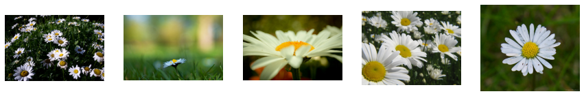

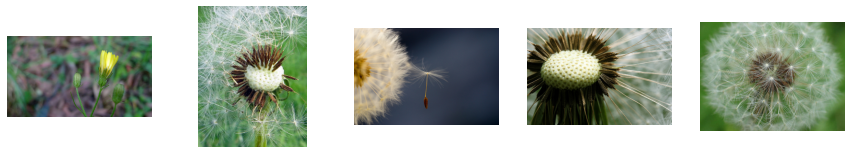

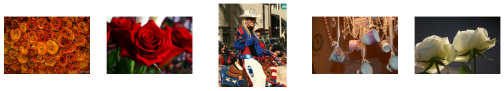

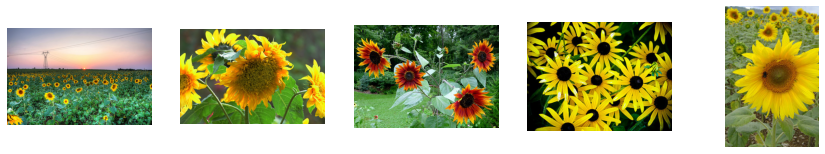

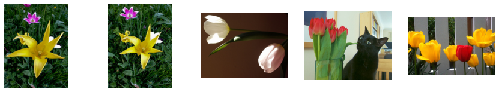

```python
# Plot some training images from the dataset
nrows = 5
ncols = 5

reset_random(seedNum)
number_elements = ncols
for c_name in class_names:
    training_class_dir = os.path.join(training_dir, c_name)
    training_class_files = os.listdir(training_class_dir)
    random_training_files = random.sample(training_class_files, number_elements)
    training_examples = [os.path.join(training_class_dir, fname) for fname in random_training_files]

    fig = plt.gcf()
    fig.set_size_inches(ncols * 3, nrows * 3)

    for i, img_path in enumerate(training_examples):
        # Set up subplot; subplot indices start at 1
        sp = plt.subplot(nrows, ncols, i + 1)
        sp.axis('Off')
        img = mpimg.imread(img_path)
        plt.imshow(img)
    plt.show()
```

```python
datagen_kwargs = dict(rescale=1./255, validation_split=VAL_SET_SIZE)
dataflow_kwargs = dict(target_size=DEFAULT_IMAGE_SIZE, batch_size=DEFAULT_BATCH, class_mode='categorical')

print('Loading and pre-processing the validation images...')
validation_datagen = ImageDataGenerator(**datagen_kwargs)
validation_generator = validation_datagen.flow_from_directory(training_dir, subset="validation", shuffle=False, **dataflow_kwargs)
print('Number of image batches per epoch of modeling:', len(validation_generator))

do_data_augmentation = True
if do_data_augmentation:
    training_datagen = ImageDataGenerator(
        rotation_range=45,
        horizontal_flip=True,
        vertical_flip=True,
        width_shift_range=0.2,
        height_shift_range=0.2,
        shear_range=0.2,
        zoom_range=0.2,
        **datagen_kwargs)
else:
    training_datagen = validation_datagen

print('\nLoading and pre-processing the training images...')
training_generator = training_datagen.flow_from_directory(training_dir, subset="training", shuffle=True, **dataflow_kwargs)
print('Number of image batches per epoch of modeling:', len(training_generator))
```

```
Loading and pre-processing the validation images...
Found 731 images belonging to 5 classes.
Number of image batches per epoch of modeling: 46

Loading and pre-processing the training images...
Found 2939 images belonging to 5 classes.
Number of image batches per epoch of modeling: 184
```

```python
if notifyStatus: status_notify('(TensorFlow Multi-Class) Task 2 - Load and Prepare Images completed on ' + datetime.now().strftime('%A %B %d, %Y %I:%M:%S %p'))
```

# Task 3 - Define and Train Models

```python
if notifyStatus: status_notify('(TensorFlow Multi-Class) Task 3 - Define and Train Models has begun on ' + datetime.now().strftime('%A %B %d, %Y %I:%M:%S %p'))
```

```python
# Define the function for plotting training results for comparison
def plot_metrics(history):
    fig, axs = plt.subplots(1, 2, figsize=(24, 15))
    metrics =  [train_loss, train_metric]
    for n, metric in enumerate(metrics):
        name = metric.replace("_"," ").capitalize()
        plt.subplot(2,2,n+1)
        plt.plot(history.epoch, history.history[metric], color='blue', label='Train')
        plt.plot(history.epoch, history.history['val_'+metric], color='red', linestyle="--", label='Val')
        plt.xlabel('Epoch')
        plt.ylabel(name)
#         if metric == train_loss:
#             plt.ylim([0, plt.ylim()[1]])
#         else:
#             plt.ylim([0.5, 1.1])
        plt.legend()
```

```python
# Define the baseline model for benchmarking
def create_nn_model(input_param=DEFAULT_IMAGE_SHAPE, output_param=NUM_CLASSES, loss_param=DEFAULT_LOSS, opt_param=DEFAULT_OPTIMIZER, metrics_param=DEFAULT_METRICS):
    nn_model = keras.applications.VGG16(include_top=True, weights=None, input_shape=input_param, classes=output_param)
    nn_model.compile(loss=loss_param, optimizer=opt_param, metrics=metrics_param)
    return nn_model
```

```python
# Initialize the neural network model and get the training results for plotting graph
startTimeModule = datetime.now()
learning_rate_reduction = ReduceLROnPlateau(monitor='val_accuracy', patience = 2, verbose=1, factor=0.5, min_lr=0.000001)
reset_random(seedNum)
nn_model_0 = create_nn_model()
nn_model_history = nn_model_0.fit(
    training_generator,
    steps_per_epoch=len(training_generator),
	validation_data=validation_generator,
    validation_steps=len(validation_generator),
    epochs=DEFAULT_EPOCH,
    callbacks=[learning_rate_reduction],
    verbose=1)
print('Total time for model fitting:', (datetime.now() - startTimeModule))
```

```
Epoch 00006: ReduceLROnPlateau reducing learning rate to 4.999999873689376e-05.

Epoch 00011: ReduceLROnPlateau reducing learning rate to 2.499999936844688e-05.

Epoch 00017: ReduceLROnPlateau reducing learning rate to 1.249999968422344e-05.

Epoch 00022: ReduceLROnPlateau reducing learning rate to 6.24999984211172e-06.

Epoch 00025: ReduceLROnPlateau reducing learning rate to 3.12499992105586e-06.
Total time for model fitting: 0:14:34.960630
```

```python
nn_model_0.summary()
```

```
Model: "vgg16"
_________________________________________________________________
Layer (type)                 Output Shape              Param #
=================================================================
input_1 (InputLayer)         [(None, 180, 180, 3)]     0
_________________________________________________________________
block1_conv1 (Conv2D)        (None, 180, 180, 64)      1792
_________________________________________________________________
block1_conv2 (Conv2D)        (None, 180, 180, 64)      36928
_________________________________________________________________
block1_pool (MaxPooling2D)   (None, 90, 90, 64)        0
_________________________________________________________________
block2_conv1 (Conv2D)        (None, 90, 90, 128)       73856
_________________________________________________________________
block2_conv2 (Conv2D)        (None, 90, 90, 128)       147584
_________________________________________________________________
block2_pool (MaxPooling2D)   (None, 45, 45, 128)       0
_________________________________________________________________
block3_conv1 (Conv2D)        (None, 45, 45, 256)       295168
_________________________________________________________________
block3_conv2 (Conv2D)        (None, 45, 45, 256)       590080
_________________________________________________________________
block3_conv3 (Conv2D)        (None, 45, 45, 256)       590080
_________________________________________________________________
block3_pool (MaxPooling2D)   (None, 22, 22, 256)       0
_________________________________________________________________
block4_conv1 (Conv2D)        (None, 22, 22, 512)       1180160
_________________________________________________________________
block4_conv2 (Conv2D)        (None, 22, 22, 512)       2359808
_________________________________________________________________
block4_conv3 (Conv2D)        (None, 22, 22, 512)       2359808
_________________________________________________________________
block4_pool (MaxPooling2D)   (None, 11, 11, 512)       0
_________________________________________________________________
block5_conv1 (Conv2D)        (None, 11, 11, 512)       2359808
_________________________________________________________________
block5_conv2 (Conv2D)        (None, 11, 11, 512)       2359808
_________________________________________________________________
block5_conv3 (Conv2D)        (None, 11, 11, 512)       2359808
_________________________________________________________________
block5_pool (MaxPooling2D)   (None, 5, 5, 512)         0
_________________________________________________________________
flatten (Flatten)            (None, 12800)             0
_________________________________________________________________
fc1 (Dense)                  (None, 4096)              52432896
_________________________________________________________________
fc2 (Dense)                  (None, 4096)              16781312
_________________________________________________________________
predictions (Dense)          (None, 5)                 20485
=================================================================
Total params: 83,949,381
Trainable params: 83,949,381
Non-trainable params: 0
_________________________________________________________________
```

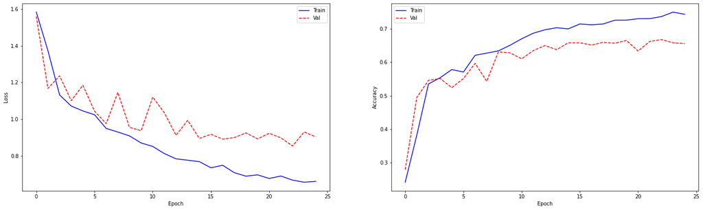

```python
plot_metrics(nn_model_history)
```

```python
if notifyStatus: status_notify('(TensorFlow Multi-Class) Task 3 - Define and Train Models completed on ' + datetime.now().strftime('%A %B %d, %Y %I:%M:%S %p'))
```

# Task 4 - Evaluate and Optimize Models

```python
if notifyStatus: status_notify('(TensorFlow Multi-Class) Task 4 - Evaluate and Optimize Models has begun on ' + datetime.now().strftime('%A %B %d, %Y %I:%M:%S %p'))
```

```python
# Not applicable for this iteration of modeling
```

```python
if notifyStatus: status_notify('(TensorFlow Multi-Class) Task 4 - Evaluate and Optimize Models completed on ' + datetime.now().strftime('%A %B %d, %Y %I:%M:%S %p'))
```

# Task 5 - Finalize Model and Make Predictions

```python
if notifyStatus: status_notify('(TensorFlow Multi-Class) Task 5 - Finalize Model and Make Predictions has begun on ' + datetime.now().strftime('%A %B %d, %Y %I:%M:%S %p'))
```

```python
datagen_kwargs = dict(rescale=1./255)
dataflow_kwargs = dict(target_size=DEFAULT_IMAGE_SIZE, batch_size=DEFAULT_BATCH, class_mode='categorical')

print('\nLoading and pre-processing the training images...')
training_datagen = ImageDataGenerator(**datagen_kwargs)
training_generator = training_datagen.flow_from_directory(training_dir, shuffle=False, **dataflow_kwargs)
print('Number of image batches per epoch of modeling:', len(training_generator))
```

```
Loading and pre-processing the training images...
Found 3670 images belonging to 5 classes.
Number of image batches per epoch of modeling: 230
```

```python
# Train the final model with the entire collection of images
FINAL_OPTIMIZER = tf.keras.optimizers.Adam(learning_rate=0.000006)
final_model = create_nn_model(opt_param=FINAL_OPTIMIZER)
final_model.fit(
    training_generator,
    steps_per_epoch=len(training_generator),
    epochs=DEFAULT_EPOCH,
    verbose=1)
print('Total time for model fitting:', (datetime.now() - startTimeModule))
```

```
Total time for model fitting: 0:39:45.647397
```

```python
# Display a summary of the final model
final_model.summary()
```

```
Model: "vgg16"
_________________________________________________________________
Layer (type)                 Output Shape              Param #
=================================================================
input_2 (InputLayer)         [(None, 180, 180, 3)]     0
_________________________________________________________________
block1_conv1 (Conv2D)        (None, 180, 180, 64)      1792
_________________________________________________________________
block1_conv2 (Conv2D)        (None, 180, 180, 64)      36928
_________________________________________________________________
block1_pool (MaxPooling2D)   (None, 90, 90, 64)        0
_________________________________________________________________
block2_conv1 (Conv2D)        (None, 90, 90, 128)       73856
_________________________________________________________________
block2_conv2 (Conv2D)        (None, 90, 90, 128)       147584
_________________________________________________________________
block2_pool (MaxPooling2D)   (None, 45, 45, 128)       0
_________________________________________________________________
block3_conv1 (Conv2D)        (None, 45, 45, 256)       295168
_________________________________________________________________
block3_conv2 (Conv2D)        (None, 45, 45, 256)       590080
_________________________________________________________________
block3_conv3 (Conv2D)        (None, 45, 45, 256)       590080
_________________________________________________________________
block3_pool (MaxPooling2D)   (None, 22, 22, 256)       0
_________________________________________________________________
block4_conv1 (Conv2D)        (None, 22, 22, 512)       1180160
_________________________________________________________________
block4_conv2 (Conv2D)        (None, 22, 22, 512)       2359808
_________________________________________________________________
block4_conv3 (Conv2D)        (None, 22, 22, 512)       2359808
_________________________________________________________________
block4_pool (MaxPooling2D)   (None, 11, 11, 512)       0
_________________________________________________________________
block5_conv1 (Conv2D)        (None, 11, 11, 512)       2359808
_________________________________________________________________
block5_conv2 (Conv2D)        (None, 11, 11, 512)       2359808
_________________________________________________________________
block5_conv3 (Conv2D)        (None, 11, 11, 512)       2359808
_________________________________________________________________
block5_pool (MaxPooling2D)   (None, 5, 5, 512)         0
_________________________________________________________________
flatten (Flatten)            (None, 12800)             0
_________________________________________________________________
fc1 (Dense)                  (None, 4096)              52432896
_________________________________________________________________
fc2 (Dense)                  (None, 4096)              16781312
_________________________________________________________________
predictions (Dense)          (None, 5)                 20485
=================================================================
Total params: 83,949,381
Trainable params: 83,949,381
Non-trainable params: 0
_________________________________________________________________
```

```python
# Print the labels used for the modeling
print(validation_generator.class_indices)
```

```
{'daisy': 0, 'dandelion': 1, 'roses': 2, 'sunflowers': 3, 'tulips': 4}
```

```python
final_model.evaluate(validation_generator, verbose=1)
```

```
[0.7650375962257385, 0.7154582738876343]
```

```python
# Make batched predictions
test_pred = final_model.predict(validation_generator)
test_predictions = np.argmax(test_pred, axis=-1)
test_original = validation_generator.labels
print('Accuracy Score:', accuracy_score(test_original, test_predictions))
print(confusion_matrix(test_original, test_predictions))
print(classification_report(test_original, test_predictions))
```

```
Accuracy Score: 0.7154582763337893
[[ 90  19  10   0   7]
 [  6 158   4   3   8]
 [  4   5  85   2  32]
 [  4  20   6  89  20]
 [  3  13  35   7 101]]
              precision    recall  f1-score   support

           0       0.84      0.71      0.77       126
           1       0.73      0.88      0.80       179
           2       0.61      0.66      0.63       128
           3       0.88      0.64      0.74       139
           4       0.60      0.64      0.62       159

    accuracy                           0.72       731
   macro avg       0.73      0.71      0.71       731
weighted avg       0.73      0.72      0.72       731
```

```python
# Make a signle prediction
flower_url = "https://storage.googleapis.com/download.tensorflow.org/example_images/592px-Red_sunflower.jpg"
flower_path = keras.utils.get_file('Red_sunflower', origin=flower_url)

img = keras.preprocessing.image.load_img(flower_path, target_size=DEFAULT_IMAGE_SIZE)
img_array = keras.preprocessing.image.img_to_array(img)
img_array = tf.expand_dims(img_array, 0) # Create a batch

predictions = final_model.predict(img_array)
score = tf.nn.softmax(predictions[0])

print("This image most likely belongs to {} with a {:.2f} percent confidence." .format(class_names[np.argmax(score)], 100 * np.max(score)))
```

```
Downloading data from https://storage.googleapis.com/download.tensorflow.org/example_images/592px-Red_sunflower.jpg
This image most likely belongs to tulips with a 40.46 percent confidence.
```

```python
if notifyStatus: status_notify('(TensorFlow Multi-Class) Task 5 - Finalize Model and Make Predictions completed on ' + datetime.now().strftime('%A %B %d, %Y %I:%M:%S %p'))
```

```python
print ('Total time for the script:',(datetime.now() - startTimeScript))
```

```
Total time for the script: 0:39:59.526579
```